# Homework 8

3. U.S. Unemployment Rate Data: The U.S. unemployment rate series can be found in the file in ur.dat off the class web page at https://edoras.sdsu.edu/~babailey/stat673/ur.dat.
1. Plot the time series, sample ACF and sample PACF.

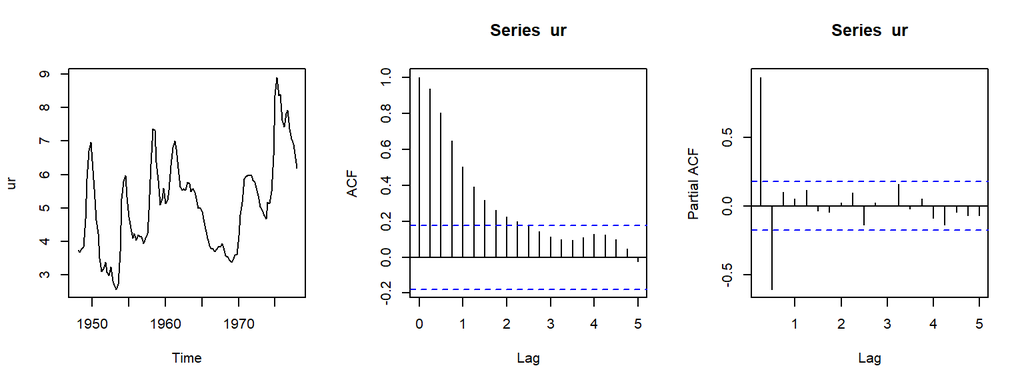

2. Is an AR(2) model appropriate for the data? Explain.

Since ACF is exponential decaying and PACF is cutoff after lag two, AR(2) can be an appropriate model the data. However, the time series is non-stationary. It seems like the unemployment rate is increasing over time.

3. Fit an AR(2) model to the data using the R function `arima`.

```r
ur.fit1 <- arima(ur, order = c(2,0,0))

ur.fit1
```

```
##
## Call:
## arima(x = ur, order = c(2, 0, 0))
##
## Coefficients:
##          ar1      ar2  intercept
##       1.5499  -0.6472     5.0815
## s.e.  0.0681   0.0686     0.3269
##
## sigma^2 estimated as 0.1276:  log likelihood = -48.76,  aic = 105.53
```

4. Make diagnostics plots using the R function tsdiag. How well does the model fit the data?

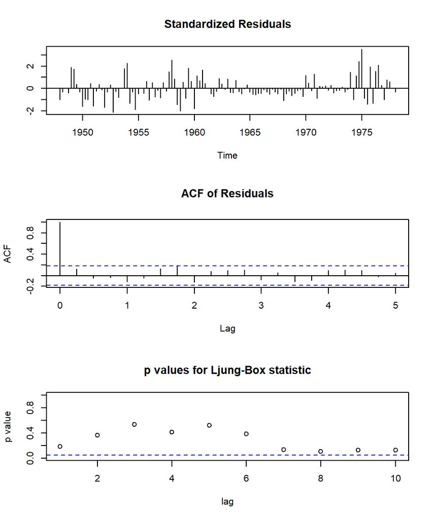

5. Use the first 115 data points to fit an AR(2) model. Forecast the next 6 observations and construct the 95% forecast limits. Include the plot. Compare your forecasts with the observations and quantify the difference.

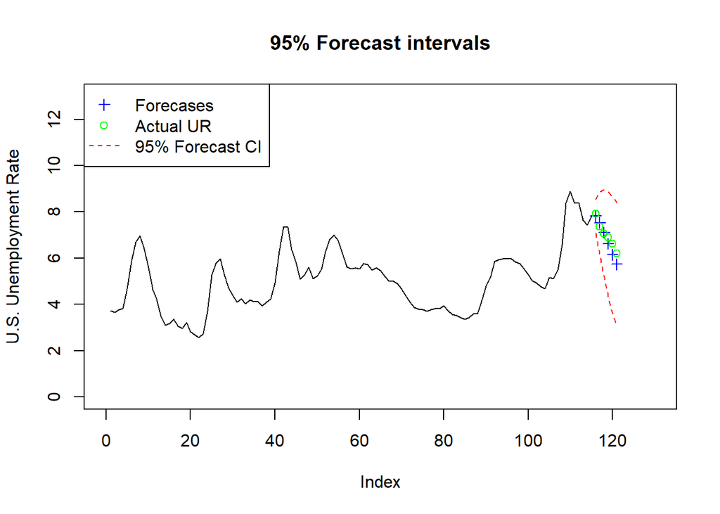

The forecasts and actual unemployment rate for these 6 observations are very close. This means that the model is predicting these test points pretty well. Since the time series is non-stationary, the 95% confident interval will be wider as we’re making more predictions.

```
##   Forecast Actual.UR Delta
## 1     7.82      7.93 -0.11
## 2     7.54      7.37  0.17
## 3     7.11      7.07  0.04
## 4     6.62      6.90 -0.28
## 5     6.15      6.63 -0.48
## 6     5.73      6.20 -0.47
```